# Homework 2

Uliana Plotnikova

September 8, 2019

### Assignment - SQL a nd R

#### Choose six recent popular movies. Ask at least five people that you know (friends, family, classmates, imaginary friends) to rate each of these movie that they have seen on a scale of 1 to 5. Take the results (observations) and store them in a SQL database. Load the information into an R dataframe. Your deliverables should include your SQL scripts and your R Markdown code, posted to GitHub. This is by design a very open ended assignment. A variety of reasonable approaches are acceptable. You can (and should) blank out your SQL password if your solution requires it; otherwise, full credit requires that your code is “reproducible,” with the assumption that I have the same database server and R software.

```r
library (knitr)
library(ggplot2)
library (RPostgreSQL)
conn <- dbConnect(
  dbDriver('PostgreSQL'),
  dbname = 'postgres',
  host = 'localhost',
  port = 5432,
  user = 'postgres',
  password = 'Ylua4786'
)
```

#### Take the results from survey and store them in a SQL database.

#### SQL code

```r
table1<-dbGetQuery(conn, 'CREATE TABLE sandbox.movie (
movie_id INT PRIMARY KEY,
movie_name VARCHAR(255) NOT NULL'
);
data1<-dbGetQuery(conn,'INSERT INTO sandbox.movie (movie_id, movie_name)
VALUES
(1, "Avengers:Endgame"),
(2, "X-Men: Dark Phenix"),
(3, "Captain Marvel"),
(4, "Terminator: Dark Fate"),
(5, "Godzilla:King of the Monsters"),
(6, "Rambo: Last Blood")'
)
table2<-dbGetQuery(conn, 'CREATE TABLE sandbox.critics (
user_id INT PRIMARY KEY,
user_name VARCHAR(55) NOT NULL'
)
data2<-dbGetQuery(conn,'INSERT INTO sandbox.critics (user_id, user_name)
VALUES
(1, "Ivan"),
(2, "Nick"),
(3, "Victoria"),
(4, "Roman"),
(5, "Arianna")'
)
table3<-dbGetQuery(conn, 'CREATE TABLE sandbox.rate (
user_id INT,
movie_id INT,
rating FLOAT'
);
table3<-dbGetQuery(conn, 'INSERT INTO sandbox.rate (user_id, movie_id, rating)
VALUES
(1, 1, "4"),
(1, 2, "2"),
(1, 3, "5"),
(1, 4, "5"),
(1, 5, "3"),
(1, 6, "3"),

(2, 1, "5"),
(2, 2, "4"),
(2, 3, "4"),
(2, 4, "5"),
(2, 5, "4"),
(2, 6, "2"),

(3, 1, "4"),
(3, 2, "2"),
(3, 3, "5"),
(3, 4, "3"),
(3, 5, "5"),
(3, 6, "1"),

(4, 1, "5"),
(4, 2, "5"),
(4, 3, "4"),
(4, 4, "2"),
(4, 5, "3"),
(4, 6, "4"),

(5, 1, "1"),
(5, 2, "4"),
(5, 3, "4"),
(5, 4, "3"),
(5, 5, "3"),
(5, 6, "5")'
)
```

[output not shown]

#### Load the information into an R dataframe.

```r
Movie<- dbGetQuery(conn, 'SELECT*FROM sandbox.movie')
```

```r
Critic<- dbGetQuery(conn, 'select * from sandbox.critics')
```

```r
Rate<- dbGetQuery(conn, 'select * from sandbox.rate')
```

```r
sql1<-dbGetQuery(conn, '
SELECT a.movie_name, r.rating, c.user_name
                    FROM sandbox.movie a
                     LEFT JOIN sandbox.rate r on a.movie_id = r.movie_id
                     LEFT JOIN sandbox.critics c ON r.user_id = c.user_id
                     ORDER BY movie_name;')
colnames(sql1) <-c("Movie", "Rating","Critic")
kable(sql1)
```

| Movie | Rating | Critic |
| --- | --- | --- |
| Avengers:Endgame | 4 | Ivan |
| Avengers:Endgame | 4 | Victoria |
| Avengers:Endgame | 1 | Arianna |
| Avengers:Endgame | 5 | Roman |
| Avengers:Endgame | 5 | Nick |
| Captain Marvel | 5 | Victoria |
| Captain Marvel | 4 | Arianna |
| Captain Marvel | 4 | Nick |
| Captain Marvel | 5 | Ivan |
| Captain Marvel | 4 | Roman |
| Godzilla:King of the Monsters | 4 | Nick |
| Godzilla:King of the Monsters | 3 | Ivan |
| Godzilla:King of the Monsters | 3 | Roman |
| Godzilla:King of the Monsters | 5 | Victoria |
| Godzilla:King of the Monsters | 3 | Arianna |
| Rambo: Last Blood | 5 | Arianna |
| Rambo: Last Blood | 3 | Ivan |
| Rambo: Last Blood | 2 | Nick |
| Rambo: Last Blood | 1 | Victoria |
| Rambo: Last Blood | 4 | Roman |
| Terminator: Dark Fate | 2 | Roman |
| Terminator: Dark Fate | 5 | Nick |
| Terminator: Dark Fate | 3 | Arianna |
| Terminator: Dark Fate | 5 | Ivan |
| Terminator: Dark Fate | 3 | Victoria |
| X-Men: Dark Phenix | 5 | Roman |
| X-Men: Dark Phenix | 2 | Victoria |
| X-Men: Dark Phenix | 2 | Ivan |
| X-Men: Dark Phenix | 4 | Arianna |
| X-Men: Dark Phenix | 4 | Nick |

## Let’s see the sum of ratings for each movie.

```r
sql2<-dbGetQuery(conn,'
  SELECT a.movie_name, Sum (r.rating)
                    FROM sandbox.movie a
                     LEFT JOIN sandbox.rate r on a.movie_id = r.movie_id
                     GROUP BY a.movie_name')

colnames(sql2) <-c("Movie", "Rating")
a<-sql2
a
```

```
##                           Movie Rating
## 1 Godzilla:King of the Monsters     18
## 2                Captain Marvel     22
## 3              Avengers:Endgame     19
## 4         Terminator: Dark Fate     18
## 5            X-Men: Dark Phenix     17
## 6             Rambo: Last Blood     15
```

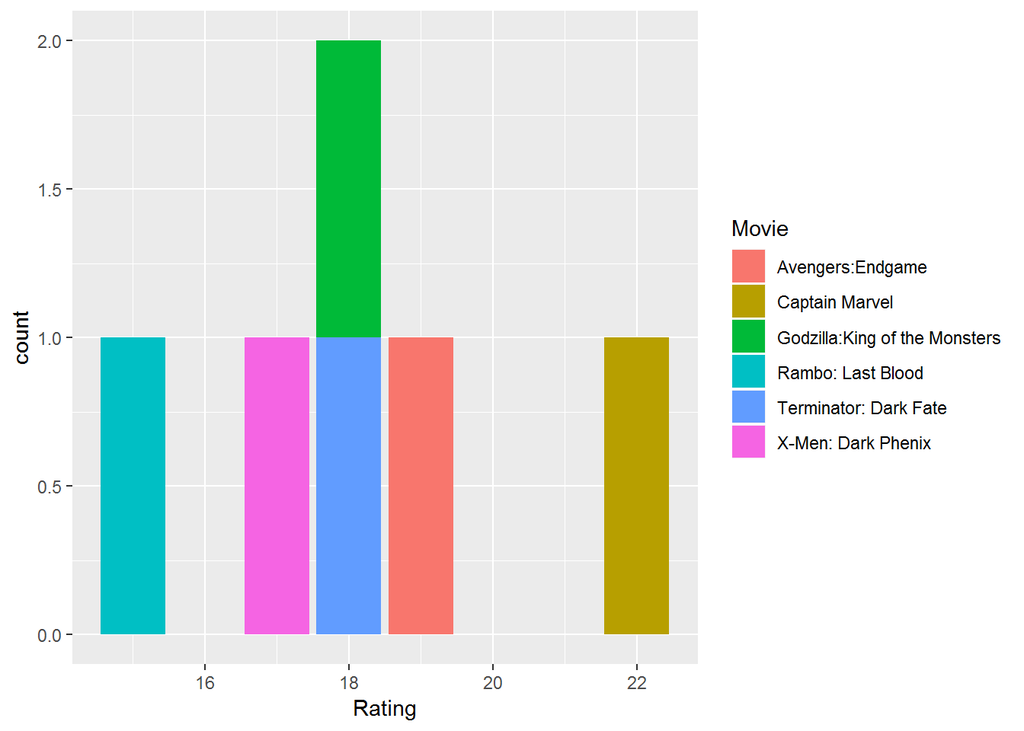

```r
ggplot(a, aes(x = Rating))+
  geom_bar(aes(fill = Movie))
```

From the data visualisation we can conclude that the ratings for movie “Terminator: Dark Fate” and “Godzilla:King of the Monsters” are the same. The lowest ratings is for “Rambo: Last Blood”" and the highest is for movie “Captain: MArvel”.